# BaiTap2_Cau03

Mu Ham Mach A Mine

2025-03-16

1. **Áp dụng thuật toán EM để ước lượng θ E-step.**

Dữ liệu quan sát được là x=(x1,x2,x3,x4)=(125,18,20,34).

Dữ liệu bị khuyết là y=(y1,y2,y3,y4,y5), trong đó x1=y1+y2, x2=y3, x3=y4, và x4=y5.

Phân phối đa thức: Dữ liệu y được phân phối theo phân phối đa thức với xác suất q=(q1,q2,q3,q4,q5).

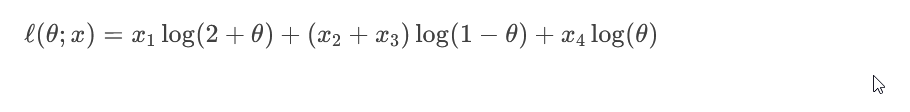

Giả sử q1=2/(2+θ), q2=θ/(2+θ), q3=1−θ, q4=1−θ, và q5=θ.

Kỳ vọng của y1 và y2: y1 và y2 là các biến ngẫu nhiên có phân phối đa thức với tổng x1=y1+y2.

Kỳ vọng của y1 và y2 được tính dựa trên xác suất của chúng trong phân phối đa thức.

Tính kỳ vọng của y1: y1 có xác suất q1=2/(2+θ).

Tính kỳ vọng của y2: y2 có xác suất q2=θ/(2+θ).

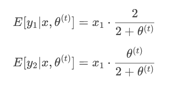

Sau khi tính được kỳ vọng của các biến bị khuyết y1 và y2 trong E-step, chúng ta cần cập nhật tham số θ sao cho hàm log-likelihood ℓ(θ;x) đạt giá trị lớn nhất.

Để tối đa hóa hàm log-likelihood ℓ(θ;x), chúng ta cần giải phương trình đạo hàm của ℓ(θ;x) theo θ và đặt bằng 0.

Đạo hàm của ℓ(θ;x) theo θ:

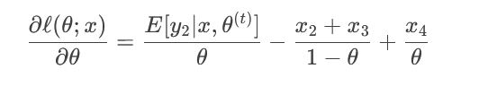

Đặt đạo hàm bằng 0 để tìm θ:

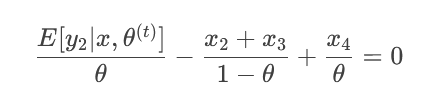

Giải phương trình để tìm θ:

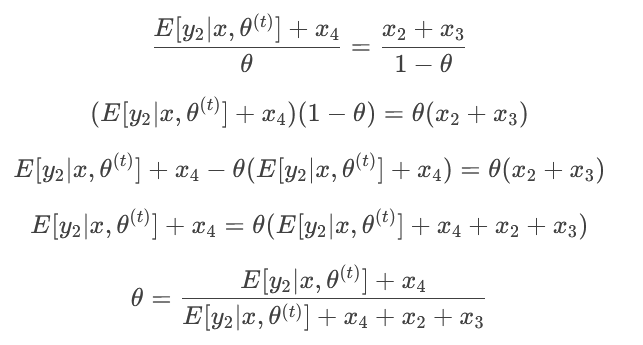

2. **Thi hành thuật toán ở câu (a), để tìm ước lượng θ.**

```r
# Dữ liệu quan sát được
x <- c(125, 18, 20, 34)

# Khởi tạo giá trị ban đầu của theta là một số ngẫu nhiên trong khoảng (0, 1)
theta <- runif(1, min = 0, max = 1)

# Điều kiện dừng: sai số giữa các lần lặp nhỏ hơn 10^-9
tolerance <- 1e-9

# Lưu lịch sử giá trị theta để vẽ biểu đồ
theta_history <- numeric(0)

# Bắt đầu vòng lặp EM
for (i in 1:1000) {  # Giới hạn tối đa 1000 bước lặp để tránh lặp vô hạn
  # E-step: Tính kỳ vọng của y1 và y2
  E_y1 <- x[1] * (2 / (2 + theta))
  E_y2 <- x[1] * (theta / (2 + theta))

  # Lưu giá trị theta cũ để tính sai số
  theta_old <- theta

  # M-step: Cập nhật theta
  theta <- (E_y2 + x[4]) / (E_y2 + x[4] + x[2] + x[3])

  # Lưu giá trị theta vào lịch sử
  theta_history <- c(theta_history, theta)

  # Tính sai số giữa các lần lặp
  error <- abs(theta - theta_old)

  # Kiểm tra điều kiện dừng
  if (error < tolerance) {
    cat("Thuật toán hội tụ sau", i, "bước lặp.\n")
    break
  }
}
```

```
## Thuật toán hội tụ sau 10 bước lặp.
```

```r
# In giá trị cuối cùng của theta
cat("Giá trị cuối cùng của theta:", theta, "\n")
```

```
## Giá trị cuối cùng của theta: 0.6268215
```

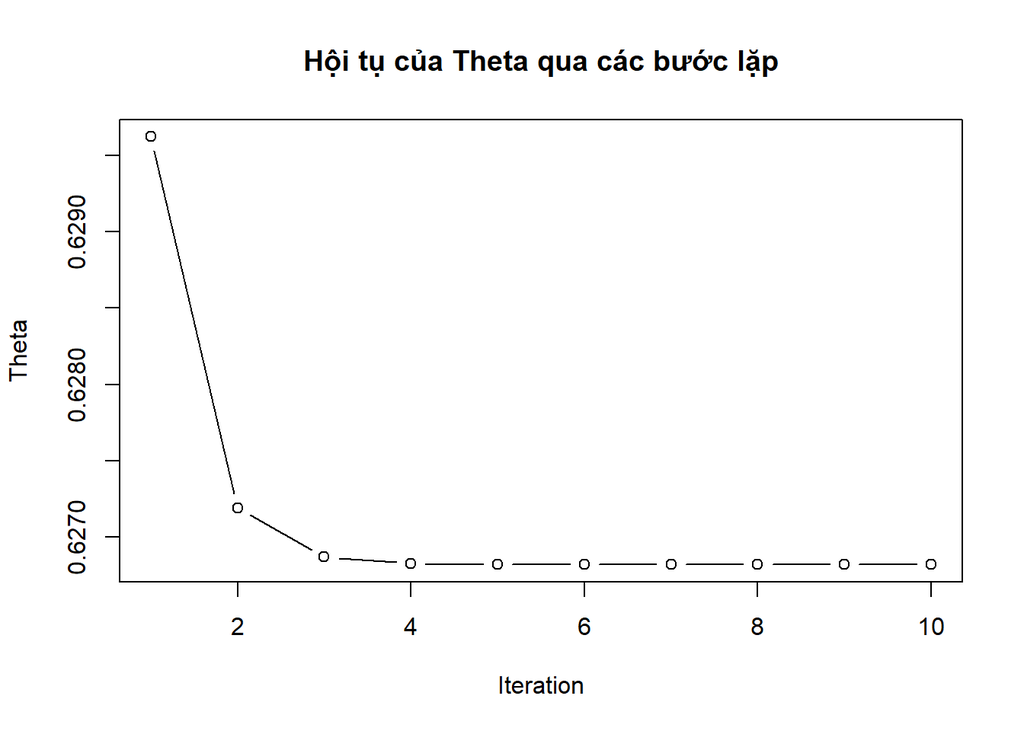

```r
# Vẽ biểu đồ hội tụ của theta
plot(theta_history, type = "b", xlab = "Iteration", ylab = "Theta", main = "Hội tụ của Theta qua các bước lặp")
```

3. **Thi hành phương pháp EM Gradient để tìm ước lượng θ dựa trên y.**

Gradient-step: Thay vì tối đa hóa hàm log-likelihood, chúng ta cập nhật θθ bằng cách sử dụng gradient của hàm log-likelihood.

Gradient của hàm log-likelihood theo θ là:

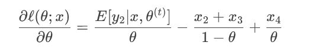

Trong phương pháp gradient, chúng ta cập nhật θ theo công thức:

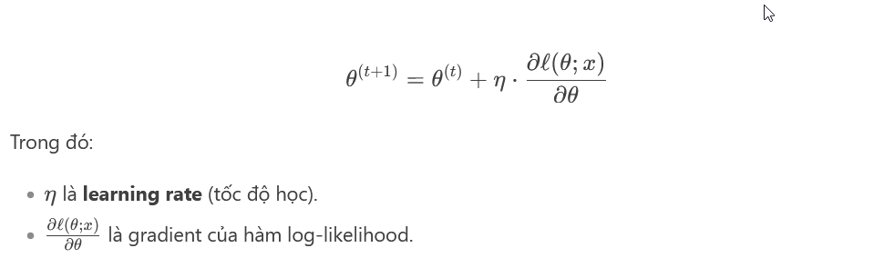

```r
# Dữ liệu quan sát được
x <- c(125, 18, 20, 34)

# Khởi tạo giá trị ban đầu của theta là một số ngẫu nhiên trong khoảng (0, 1)
theta <- runif(1, min = 0, max = 1)

# Learning rate (tốc độ học)
eta <- 0.0001

# Điều kiện dừng: sai số giữa các lần lặp nhỏ hơn 10^-9
tolerance <- 1e-9

# Lưu lịch sử giá trị theta để vẽ biểu đồ
theta_history <- numeric(0)

# Bắt đầu vòng lặp EM Gradient
for (i in 1:1000) {  # Giới hạn số bước lặp
  # E-step: Tính kỳ vọng của y2
  E_y2 <- x[1] * (theta / (2 + theta))

  # Tính gradient của hàm log-likelihood
  gradient <- (E_y2 / theta) - ((x[2] + x[3]) / (1 - theta)) + (x[4] / theta)

  # Gradient clipping: Giới hạn gradient để tránh cập nhật quá mức
  gradient <- ifelse(abs(gradient) > 100, sign(gradient) * 100, gradient)

  # Lưu giá trị theta cũ để tính sai số
  theta_old <- theta

  # Cập nhật theta bằng phương pháp gradient
  theta <- theta + eta * gradient

  # Giới hạn giá trị của theta trong khoảng (0, 1)
  theta <- ifelse(theta < 0, 0.001, theta)
  theta <- ifelse(theta > 1, 0.999, theta)

  # Lưu giá trị theta vào lịch sử
  theta_history <- c(theta_history, theta)

  # Tính sai số giữa các lần lặp
  error <- abs(theta - theta_old)

  # Kiểm tra điều kiện dừng
  if (error < tolerance) {
    cat("Phương pháp EM Gradient hội tụ sau", i, "bước lặp.\n")
    break
  }
}
```

```
## Phương pháp EM Gradient hội tụ sau 398 bước lặp.
```

```r
# In giá trị cuối cùng của theta
cat("Giá trị cuối cùng của theta:", theta, "\n")
```

```
## Giá trị cuối cùng của theta: 0.6268215
```

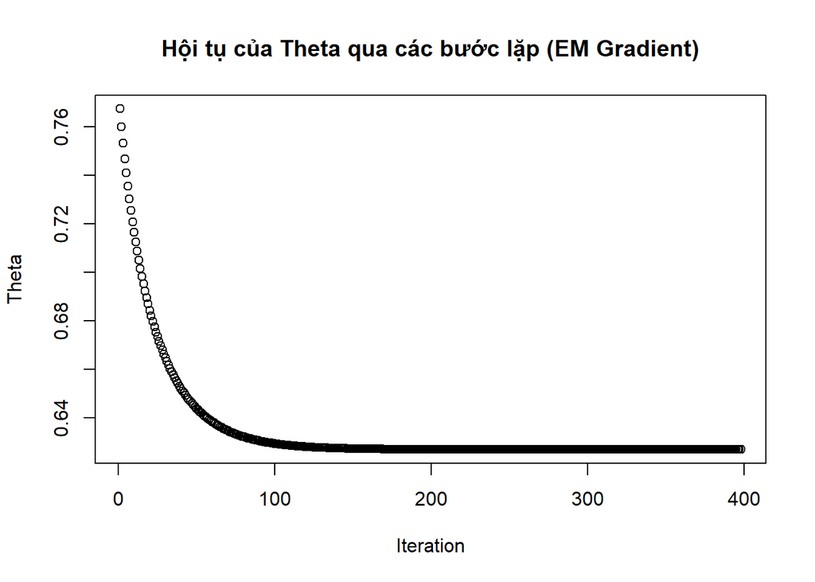

```r
# Vẽ biểu đồ hội tụ của theta
plot(theta_history, type = "b", xlab = "Iteration", ylab = "Theta", main = "Hội tụ của Theta qua các bước lặp (EM Gradient)")
```

4. **Thi hành phương pháp quasi-Newton EM tìm ước lượng θ dựa trên y.**

E-step: Tính kỳ vọng của các biến bị khuyết y1 và y2 dựa trên giá trị hiện tại của θ.

Quasi-Newton-step: Sử dụng phương pháp tối ưu hóa bậc hai (như BFGS) để cập nhật θ bằng cách tối đa hóa hàm log-likelihood.

Cập nhật tham số θ

Tại mỗi bước lặp, tham số θ được cập nhật theo công thức:

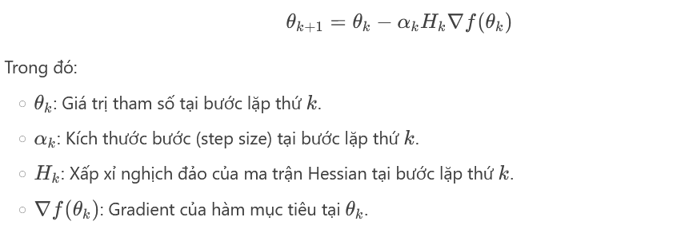

Cập nhật xấp xỉ Hessian

Xấp xỉ Hessian được cập nhật qua các bước lặp theo công thức BFGS:

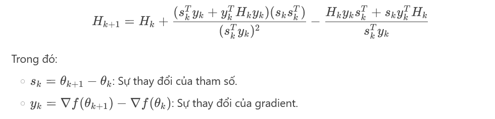

```
## Thuật toán hội tụ sau 8 bước lặp.
```

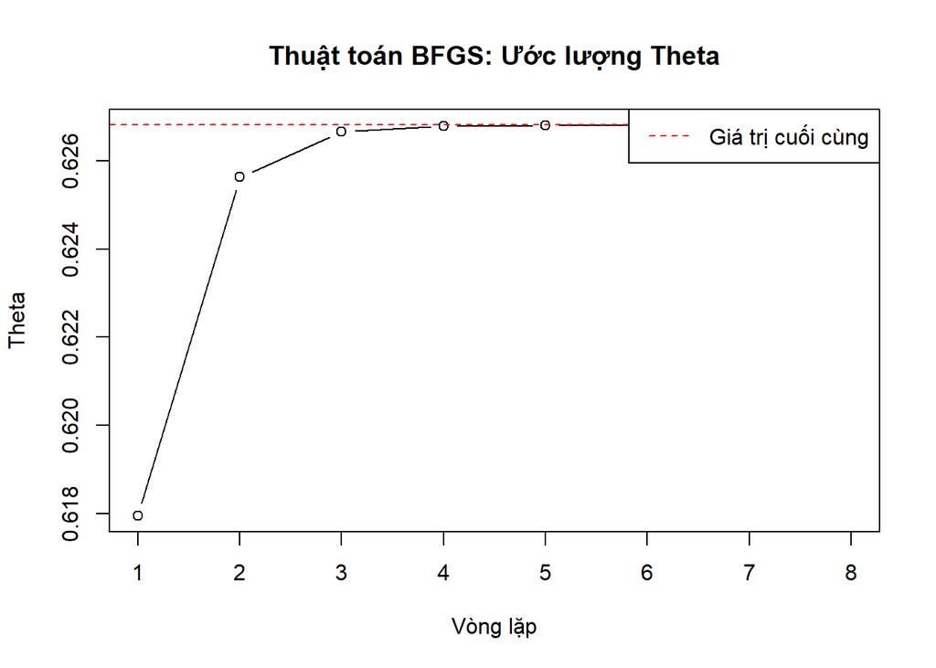

```r
quasi_newton_em <- function(x, theta, tol = 1e-6, max_iter = 1000) {
  # Lưu lịch sử giá trị theta để vẽ đồ thị
  theta_history <- numeric(max_iter)

  for (i in 1:max_iter) {
    # Bước E: Tính các giá trị kỳ vọng
    y2 <- x[1] * (theta / (2 + theta))
    y1 <- x[1] - y2

    # Bước M: Cập nhật theta sử dụng phương pháp BFGS
    opt <- optim(theta, function(theta) {
      # Đảm bảo theta nằm trong khoảng (0, 1)
      if (theta <= 0 || theta >= 1) {
        return(Inf)  # Trả về giá trị lớn để tránh theta không hợp lệ
      }
      - (y2 + x[4]) * log(theta) - (x[2] + x[3]) * log(1 - theta)
    }, method = "BFGS")  # Sử dụng phương pháp BFGS

    theta_new <- opt$par

    # Lưu giá trị theta để vẽ đồ thị
    theta_history[i] <- theta_new

    # Kiểm tra sự hội tụ
    if (abs(theta_new - theta) < tol) {
      theta_history <- theta_history[1:i]  # Cắt bỏ các giá trị thừa
      cat("Thuật toán hội tụ sau", i, "bước lặp.\n")
      break
    }
    theta <- theta_new
  }

  # Vẽ đồ thị theta qua các vòng lặp
  plot(1:length(theta_history), theta_history, type = "b",
       xlab = "Vòng lặp", ylab = "Theta",
       main = "Thuật toán BFGS: Ước lượng Theta")
  abline(h = theta, col = "red", lty = 2)  # Đường thẳng thể hiện giá trị cuối cùng
  legend("topright", legend = c("Giá trị cuối cùng"), col = "red", lty = 2)

  return(theta)
}

# Dữ liệu quan sát được
x <- c(125, 18, 20, 34)

# Khởi tạo giá trị ban đầu của theta là một số ngẫu nhiên trong khoảng (0, 1)
theta_init <- runif(1, min = 0, max = 1)

# Chạy thuật toán BFGS
theta_bfgs_est <- quasi_newton_em(x, theta_init)
```

```r
cat("Ước lượng Theta từ thuật toán BFGS:", theta_bfgs_est, "\n")
```

```
## Ước lượng Theta từ thuật toán BFGS: 0.6268198
```